# Wetland Inundation Mapping through Remote Sensing and Ethnographic Validation

#### 2.2.B SAR Backscatter Processing

SAR processing exploits the sensitivity of C-band radar to backscatter differences between smooth water surfaces and rough terrestrial features. Calm water yields low backscatter (-20 to -30 dB) while vegetated areas exhibit higher returns from volume scattering and surface roughness interactions. Wet soils produce higher backscatter than dry soils due to their increased dielectric constant. VV polarisation provides greatest sensitivity to soil moisture; cross-polarisation (VH) differentiates woody from herbaceous vegetation (Tsyganskaya et al., 2018).

Sentinel-1 data were processed through a Google Earth Engine pipeline that handles radiometric calibration, speckle filtering, and geometric correction at scale. GEE provides access to the full Sentinel-1 Ground Range Detected archive, pre-processed to sigma-0 backscatter coefficients with thermal noise removal, radiometric calibration, and terrain correction applied (Gorelick et al., 2017). We filter the archive to Interferometric Wide Swath mode with VV and VH polarisations in descending orbit.

```{r s1-query} s1 <- ee$ImageCollection(“COPERNICUS/S1_GRD”)$ filterBounds(aoi_ee)$ filter(ee$Filter$eq(“instrumentMode”, “IW”))$ filter(ee$Filter$listContains(“transmitterReceiverPolarisation”, “VV”))$ filter(ee$Filter$listContains(“transmitterReceiverPolarisation”, “VH”))$ filter(ee$Filter$eq(“orbitProperties_pass”, “DESCENDING”))$ select(c(“VV”, “VH”, “angle”))

n_scenes <- s1$size()$getInfo() print(paste(“Total Sentinel-1 scenes:”, n_scenes))

# Date range

dates <- s1$reduceColumns( ee$Reducer$minMax(), list(“system:time_start”))$getInfo() print(paste(“First scene:”, as.Date(as.POSIXct(dates[[1]] / 1000, origin = “1970-01-01”)))) print(paste(“Last scene:”, as.Date(as.POSIXct(dates[[2]] / 1000, origin = “1970-01-01”))))

````
##### Speckle Filtering

GEE does not apply speckle filtering by default. We implement a focal mean approximation. For refined Lee Sigma filtering, export to SNAP. The focal approach is sufficient for time series compositing where multi-temporal averaging further suppresses speckle.

```{r speckle-filter}
apply_speckle_filter <- function(image) {
  # Focal mean with 7x7 kernel (approximates boxcar filter)
  vv_filtered <- image$select("VV")$focal_mean(radius = 3.5, kernelType = "square", units = "pixels")$rename("VV_filtered")
  vh_filtered <- image$select("VH")$focal_mean(radius = 3.5, kernelType = "square", units = "pixels")$rename("VH_filtered")
  image$addBands(vv_filtered)$addBands(vh_filtered)$copyProperties(image, list("system:time_start"))}

s1_filtered <- s1$map(apply_speckle_filter)
````

##### Backscatter Ratio Bands

VV/VH ratio and band difference help distinguish open water from flooded vegetation. Open water shows low VV and low VH. Flooded vegetation shows moderate VV but elevated VH due to double-bounce scattering.

```{r ratio-bands} # Ratio (in dB domain, ratio = difference) add_ratio_bands <- function(image) { vv <- image$select(“VV_filtered”) vh <- image$select(“VH_filtered”) ratio <- vv$subtract(vh)$rename(“VV_VH_ratio”) nd <- vv$subtract(vh)$divide(vv$add(vh))$rename(“VV_VH_nd”) image$addBands(ratio)$addBands(nd)$copyProperties(image, list(“system:time_start”))}

s1_processed <- s1_filtered$map(add_ratio_bands)

````
##### Water Detection Thresholding

Calm water surfaces yield low backscatter in both VV and VH channels, typically below -15 dB for VV. We use a percentile-based adaptive threshold: compute the VV distribution within the AOI on a reference scene and take the value that separates the lowest backscatter mode (water) from land. A fixed fallback of -15 dB is available if needed.

```{r water-threshold}
# Reference scene for threshold calibration
sample_image <- ee$Image(s1_processed$first())$select("VV_filtered")

# Compute percentile-based threshold within AOI
# The 15th percentile of VV typically captures the water/land break
# in scenes with substantial water coverage like Chilwa
percentiles <- sample_image$reduceRegion(
  reducer = ee$Reducer$percentile(c(15L, 50L)),
  geometry = aoi_ee,
  scale = 30L,
  maxPixels = as.integer(1e9)
)$getInfo()

threshold_vv <- percentiles$VV_filtered_p15
print(paste("Adaptive VV threshold (p15):", round(threshold_vv, 2), "dB"))
print(paste("Median VV:", round(percentiles$VV_filtered_p50, 2), "dB"))

# Use adaptive threshold; fall back to -15 dB if percentile is unreasonable
if (is.null(threshold_vv) || threshold_vv > -10 || threshold_vv < -25) {
  threshold_vv <- -15
  print("Using fixed threshold: -15 dB")
}

classify_water <- function(image) {
  water <- image$select("VV_filtered")$lt(threshold_vv)$rename("water")
  image$addBands(water)$
    copyProperties(image, list("system:time_start"))
}

s1_water <- s1_processed$map(classify_water)
````

##### Monthly Composites

Aggregate to monthly composites to reduce data volume and suppress residual speckle through temporal averaging.

```{r monthly-composites} # Build year-month pairs in the cloud before writing locally year_month_pairs <- expand.grid(year = 2015L:2024L, month = 1L:12L) composite_list <- lapply(seq_len(nrow(year_month_pairs)), function(i) { y <- as.integer(year_month_pairs$year[i]) m <- as.integer(year_month_pairs$month[i]) start <- ee$Date$fromYMD(y, m, 1L) end <- start$advance(1L, “month”) monthly <- s1_water$filterDate(start, end) n <- monthly$size()$getInfo() if (n == 0L) return(NULL) monthly$mean()$ set(“system:time_start”, start$millis())$ set(“year”, y)$ set(“month”, m)$ set(“n_scenes”, n)})

# Drop empty months

composite_list <- Filter(Negate(is.null), composite_list) s1_monthly <- ee$ImageCollection$fromImages(composite_list) print(paste(“Monthly composites:”, length(composite_list)))

````
##### Time Series Extraction

Extract mean backscatter and water fraction within the AOI for each monthly composite to build the SAR time series.

```{r time-series}
extract_stats <- function(image) {
  stats <- image$select(c("VV_filtered", "VH_filtered", "water"))$
    reduceRegion(

      reducer = ee$Reducer$mean(),
      geometry = aoi_ee,
      scale = 30L,
      maxPixels = as.integer(1e9)
    )
  ee$Feature(NULL, stats)$
    set("date", image$date()$format("YYYY-MM-dd"))$
    set("year", image$get("year"))$
    set("month", image$get("month"))$
    set("n_scenes", image$get("n_scenes"))
}

s1_ts <- s1_monthly$map(extract_stats)
s1_ts_info <- s1_ts$getInfo()

# Convert to data frame
s1_df <- do.call(rbind, lapply(s1_ts_info$features, function(f) {
  data.frame(
    date        = f$properties$date,
    year        = f$properties$year,
    month       = f$properties$month,
    n_scenes    = f$properties$n_scenes,
    VV_mean     = f$properties$VV_filtered,
    VH_mean     = f$properties$VH_filtered,
    water_frac  = f$properties$water,
    stringsAsFactors = FALSE)}))

s1_df$date <- as.Date(s1_df$date)
print(head(s1_df))
````

Multi-temporal gradient analysis, adapted from sea ice monitoring methodologies, enhanced detection of dynamic water boundaries through comparative analysis of seasonal backscatter patterns. This approach proved effective for identifying transitions between open water, flooded vegetation, and terrestrial surfaces, and for tracking the recession-refilling wavefront described in Section 3.3.

##### Visualise

Map a wet-season and dry-season composite side by side.

```{r map-composites} # Compare months in wet and dry seasons wet <- s1_monthly$ filter(ee$Filter$eq(“month”, 1L))$ filter(ee$Filter$eq(“year”, 2020L))$first()

dry <- s1_monthly$ filter(ee$Filter$eq(“month”, 8L))$ filter(ee$Filter$eq(“year”, 2020L))$first()

vis_sar <- list(bands = list(“VV_filtered”), min = -25, max = 0,palette = c(“black”, “white”)) vis_water <- list(bands = list(“water”), min = 0, max = 1,palette = c(“white”, “blue”)) wet_sar_url <- ee_tile_url(wet$clip(aoi_ee), vis_sar) dry_sar_url <- ee_tile_url(dry$clip(aoi_ee), vis_sar) wet_water_url <- ee_tile_url(wet$clip(aoi_ee), vis_water) dry_water_url <- ee_tile_url(dry$clip(aoi_ee), vis_water)

tmap_mode(“view”) tm_shape(st_as_sf(aoi_sf)) + tm_borders(col = “red”, lwd = 2) + tm_basemap(“Esri.WorldImagery”) + tm_tiles(wet_sar_url, group = “Wet VV (Jan 2020)”) + tm_tiles(wet_water_url, group = “Wet water mask (Jan 2020)”) + tm_scalebar(position = c(“right”, “bottom”)) -> map_wet

tm_shape(st_as_sf(aoi_sf)) + tm_borders(col = “red”, lwd = 2) + tm_basemap(“Esri.WorldImagery”) + tm_tiles(dry_sar_url, group = “Dry VV (Aug 2020)”) + tm_tiles(dry_water_url, group = “Dry water mask (Aug 2020)”) + tm_scalebar(position = c(“right”, “bottom”)) -> map_dry

tmap_arrange(map_wet, map_dry, ncol = 2)

````
##### Export SAR Time Series

```{r export}
write.csv(s1_df, "../03.outputs/s1_monthly_timeseries.csv", row.names = FALSE)

# To export a composite as GeoTIFF (uncomment and run as needed):
# task <- ee$batch$Export$image$toDrive(
#   image = wet$select(c("VV_filtered", "VH_filtered", "water"))$clip(aoi_ee),
#   description = "S1_wet_2020_01",
#   folder = "GEE_exports",
#   region = aoi_ee,
#   scale = 10L,
#   maxPixels = as.integer(1e9)
# )
# task$start()
````

GEE Sentinel-1 GRD products arrive with radiometric calibration (sigma0) and Range-Doppler terrain correction already applied. The processing chain here adds speckle filtering (focal mean, 7x7), polarimetric ratio bands, adaptive VV water thresholding, and monthly compositing. For interferometric analysis or refined Lee Sigma filtering, export raw scenes to SNAP.

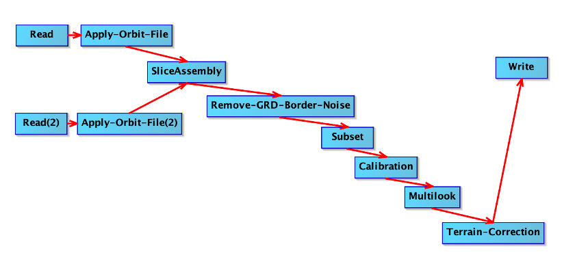

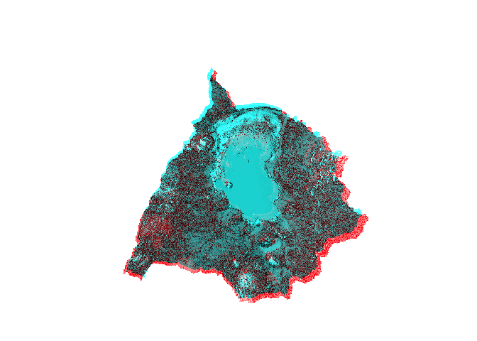

#### 2.2.C Landsat Image Processing

Optical analysis used Analysis Ready Data products from Landsat Collection 2, accessed through Google Earth Engine, specifically Level-2 surface reflectance from the Thematic Mapper (L5-TM), Enhanced Thematic Mapper Plus (L7-ETM+), and Operational Land Imager (L8-OLI). Band names were harmonised to a common six-band schema (blue, green, red, NIR, SWIR1, SWIR2) across the three sensor families to enable consistent index computation. Collection 2 scale factors were applied (reflectance = DN x 0.0000275 - 0.2) and cloud and shadow pixels masked using the QA_PIXEL bitfield band. Scenes exceeding 30% cloud cover were excluded. Earlier sensors (Landsat 3 and 4) were evaluated but present gaps, cloud interference, sensor degradation, and archival quality issues that reduce usable coverage, particularly before 1984; the temporal window is constrained by these data quality limitations rather than by methodological choice. Annual median composites were generated for each index, forming the core multi-decadal time series for characterising recession-refilling cycles.

```{r landsat-query} l5_bands <- list(from = c(“SR_B1”,“SR_B2”,“SR_B3”,“SR_B4”,“SR_B5”,“SR_B7”), to = c(“blue”,“green”,“red”,“nir”,“swir1”,“swir2”)) l7_bands <- l5_bands l8_bands <- list(from = c(“SR_B2”,“SR_B3”,“SR_B4”,“SR_B5”,“SR_B6”,“SR_B7”), to = c(“blue”,“green”,“red”,“nir”,“swir1”,“swir2”))

apply_scale <- function(image) { optical <- image$select(“SR_B.*“)$multiply(0.0000275)$add(-0.2) image$addBands(optical, overwrite = TRUE)$copyProperties(image, list(”system:time_start”)) } mask_clouds <- function(image) { qa <- image$select(“QA_PIXEL”) mask <- qa$bitwiseAnd(bitwShiftL(1L,3L))$eq(0L)$And(qa$bitwiseAnd(bitwShiftL(1L,4L))$eq(0L)) image$updateMask(mask)$copyProperties(image, list(“system:time_start”)) } harmonise <- function(image, from, to) image$select(from, to)$copyProperties(image, list(“system:time_start”))

l5_col <- ee$ImageCollection(“LANDSAT/LT05/C02/T1_L2”)$filterBounds(aoi_ee)$ filter(ee$Filter$lt(“CLOUD_COVER”, 30))$map(mask_clouds)$map(apply_scale)$ map(function(img) harmonise(img, l5_bands$from, l5_bands$to)) l7_col <- ee$ImageCollection(“LANDSAT/LE07/C02/T1_L2”)$filterBounds(aoi_ee)$ filter(ee$Filter$lt(“CLOUD_COVER”, 30))$map(mask_clouds)$map(apply_scale)$ map(function(img) harmonise(img, l7_bands$from, l7_bands$to)) l8_col <- ee$ImageCollection(“LANDSAT/LC08/C02/T1_L2”)$filterBounds(aoi_ee)$ filter(ee$Filter$lt(“CLOUD_COVER”, 30))$map(mask_clouds)$map(apply_scale)$ map(function(img) harmonise(img, l8_bands$from, l8_bands$to))

landsat <- l5_col$merge(l7_col)$merge(l8_col)$sort(“system:time_start”)

n_landsat <- landsat$size()$getInfo() print(paste(“Total harmonised Landsat scenes:”, n_landsat))

ls_dates <- landsat$reduceColumns( ee$Reducer$minMax(), list(“system:time_start”))$getInfo() print(paste(“First scene:”, as.Date(as.POSIXct(ls_dates$min / 1000, origin = “1970-01-01”)))) print(paste(“Last scene:”, as.Date(as.POSIXct(ls_dates$max / 1000, origin = “1970-01-01”))))

````
#### 2.2.D Spectral Water Indices

Five water-extraction indices were evaluated, selected to span the range of spectral approaches available for inland water mapping and to test their relative performance under the specific conditions Lake Chilwa presents:

1.  NDWI (McFeeters, 1996): (Green - NIR) / (Green + NIR). The original water index, sensitive to deep open water but prone to false negatives in turbid, shallow, or vegetated conditions due to elevated NIR reflectance from suspended sediment and canopy effects. Serves as the baseline against which other indices are compared.

2.  MNDWI (Xu, 2006): (Green - SWIR1) / (Green + SWIR1). Substitutes SWIR for NIR, improving discrimination of water from built-up and bare-soil surfaces. The strongest single optical index for turbid water detection, though it fails beneath emergent vegetation and requires adaptive thresholding in saline systems.

3.  AWEIsh (Feyisa et al., 2014): Blue + 2.5 x Green - 1.5 x (NIR + SWIR1) - 0.25 x SWIR2. A five-band combination optimised for shadow suppression and complex landscape discrimination. Outperforms simpler indices where topographic or shadow effects confound classification but offers no clear advantage in shallow vegetated wetlands.

4.  WRI (Shen and Li, 2010): (Green + Red) / (NIR + SWIR1). A ratio index that suppresses cloud and shadow noise effectively. Competitive in bare-soil landscapes but vulnerable to inflation from suspended sediment in the red band and untested in endorheic systems.

5.  NDPI (Lacaux et al., 2007): (SWIR1 - Green) / (SWIR1 + Green). Designed for temporary pond detection in semi-arid Africa using SPOT-5 data. The algebraic inverse of MNDWI, sensitive to the water-vegetation boundary where other indices fail. Most ecologically appropriate for Lake Chilwa's seasonal vegetated margins but loses sensitivity in deep or turbid water.

```{r spectral-indices}
compute_indices <- function(image) {
  blue<-image$select("blue"); green<-image$select("green"); red<-image$select("red")
  nir<-image$select("nir"); swir1<-image$select("swir1"); swir2<-image$select("swir2")
  ndwi   <- green$subtract(nir)$divide(green$add(nir))$rename("NDWI")
  mndwi  <- green$subtract(swir1)$divide(green$add(swir1))$rename("MNDWI")
  aweish <- blue$add(green$multiply(2.5))$subtract(nir$add(swir1)$multiply(1.5))$
    subtract(swir2$multiply(0.25))$rename("AWEIsh")
  wri    <- green$add(red)$divide(nir$add(swir1))$rename("WRI")
  ndpi   <- swir1$subtract(green)$divide(swir1$add(green))$rename("NDPI")
  image$addBands(c(ndwi, mndwi, aweish, wri, ndpi))$copyProperties(image, list("system:time_start"))
}
landsat_idx <- landsat$map(compute_indices)
print("Spectral indices computed: NDWI, MNDWI, AWEIsh, WRI, NDPI")
````

The multi-index approach tests each against SAR-derived water maps to quantify what optical sensors detect and what they miss across the basin’s full range of conditions.

`{r annual-composites} years <- 1984L:2024L index_bands <- c("NDWI","MNDWI","AWEIsh","WRI","NDPI","blue","green","red","nir","swir1","swir2") annual_composites <- lapply(years, function(y) { start <- ee$Date$fromYMD(y, 1L, 1L); end <- ee$Date$fromYMD(y, 12L, 31L) annual <- landsat_idx$filterDate(start, end)$select(index_bands) n <- annual$size()$getInfo() if (n == 0L) return(NULL) annual$median()$set("system:time_start", start$millis())$set("year", y)$set("n_scenes", n) }) annual_composites <- Filter(Negate(is.null), annual_composites) landsat_annual <- ee$ImageCollection$fromImages(annual_composites) print(paste("Annual composites:", length(annual_composites)))`

```{r index-timeseries} extract_index_stats <- function(image) { stats <- image$select(c(“NDWI”, “MNDWI”, “AWEIsh”, “WRI”, “NDPI”))$ reduceRegion( reducer = ee$Reducer$mean(), geometry = aoi_ee, scale = 30L, maxPixels = as.integer(1e9) ) ee$Feature(NULL, stats)$ set(“year”, image$get(“year”))$ set(“n_scenes”, image$get(“n_scenes”)) }

ls_ts_info <- landsat_annual$map(extract_index_stats)$getInfo()

ls_df <- do.call(rbind, lapply(ls_ts_info$features, function(f) { data.frame( year = f$properties$year, n_scenes = f$properties$n_scenes, NDWI = f$properties$NDWI, MNDWI = f$properties$MNDWI, AWEIsh = f$properties$AWEIsh, WRI = f$properties$WRI, NDPI = f$properties$NDPI, stringsAsFactors = FALSE) }))

print(head(ls_df))

````
```{r index-timeseries-plot}
ls_long <- ls_df %>%
  pivot_longer(cols = c(NDWI, MNDWI, AWEIsh, WRI, NDPI),
               names_to = "index", values_to = "value")

ggplot(ls_long, aes(x = year, y = value, colour = index)) +
  geom_line(linewidth = 0.8) +
  geom_point(size = 1.5) +
  geom_vline(xintercept = c(1995, 2012), linetype = "dashed",
             colour = "grey40", linewidth = 0.5) +
  labs(title = "Lake Chilwa: Spectral Water Indices (1984-2024)",
       x = "Year", y = "Index value (basin mean)",
       colour = "Index") +
  theme_minimal() +
  theme(legend.position = "bottom")
````

To address threshold instability caused by dissolved salts, algal blooms, and variable turbidity in the endorheic system, an Otsu-style percentile method was applied to derive adaptive water/non-water thresholds, following Pekel et al. (2016). Basin-wide MNDWI percentiles for a 2020 dry-season composite illustrate the bimodal distribution exploited by the method.

`{r otsu-threshold} ref_scene <- landsat_idx$filterDate("2020-06-01", "2020-10-31")$median()$clip(aoi_ee) mndwi_vals <- ref_scene$select("MNDWI")$reduceRegion( reducer = ee$Reducer$percentile(c(10L, 50L, 90L)), geometry = aoi_ee, scale = 30L, maxPixels = as.integer(1e9))$getInfo() print(paste("MNDWI p10:", round(mndwi_vals$MNDWI_p10, 4))) print(paste("MNDWI p50:", round(mndwi_vals$MNDWI_p50, 4))) print(paste("MNDWI p90:", round(mndwi_vals$MNDWI_p90, 4)))`

#### 2.2.E Spectral Mixture Analysis

Spectral mixture analysis enabled sub-pixel water fraction estimation, critical for monitoring gradual transitions between terrestrial and aquatic habitats. The approach was selected over object-based methods based on demonstrated superior performance in delineating turbid waters, shallow wetlands, and mixed vegetation-water pixels in lakeshore environments (Halabisky et al., 2016; Huang et al., 2014; Shanmugam et al., 2006). The spectral characteristics of Lake Chilwa, with its dense marshlands, shallow waters, extensive detritus, phytoplankton blooms, and shoreline shadowing, make sub-pixel estimation essential.

Endmember selection followed standard protocols, with training samples drawn from spectrally pure pixels identified through iterative refinement and community validation: open water (129 samples, purity threshold >95%), flooded vegetation (117 samples, >85%), dry vegetation (69 samples, >90%), bare soil (42 samples, >85%), and urban/built (28 samples, >90%).

```{r sma-endmembers} # Define endmembers from spectrally pure pixels within the AOI. # Values represent typical surface reflectance (blue, green, red, nir, swir1, swir2) # for each cover type in the Lake Chilwa basin. endmembers_water <- c(0.02, 0.03, 0.02, 0.01, 0.001, 0.001) endmembers_flooded_veg <- c(0.03, 0.05, 0.04, 0.15, 0.06, 0.03) endmembers_dry_veg <- c(0.04, 0.06, 0.05, 0.30, 0.20, 0.10) endmembers_bare_soil <- c(0.10, 0.12, 0.14, 0.18, 0.25, 0.22) endmembers_urban <- c(0.08, 0.09, 0.10, 0.12, 0.15, 0.14)

endmember_list <- list(endmembers_water, endmembers_flooded_veg, endmembers_dry_veg, endmembers_bare_soil, endmembers_urban)

````
```{r sma-unmix}
# Apply SMA to the 2020 dry-season composite
ref_bands <- ref_scene$select(c("blue", "green", "red", "nir", "swir1", "swir2"))

fractions <- ref_bands$unmix(
  endmembers = endmember_list,
  sumToOne = TRUE,
  nonNegative = TRUE
)$rename(c("water_frac", "flooded_veg_frac", "dry_veg_frac",
           "bare_soil_frac", "urban_frac"))

vis_frac <- list(bands = list("water_frac"), min = 0, max = 1,
                 palette = c("white", "cyan", "blue", "darkblue"))
frac_url <- ee_tile_url(fractions$clip(aoi_ee), vis_frac)

tmap_mode("view")
tm_shape(st_as_sf(aoi_sf)) +
  tm_borders(col = "red", lwd = 2) +
  tm_basemap("Esri.WorldImagery") +
  tm_tiles(frac_url, group = "SMA water fraction") +
  tm_scalebar(position = c("right", "bottom"))
````

```{r sma-timeseries} unmix_image <- function(image) { bands <- image$select(c(“blue”, “green”, “red”, “nir”, “swir1”, “swir2”)) fracs <- bands$unmix( endmembers = endmember_list, sumToOne = TRUE, nonNegative = TRUE )$rename(c(“water_frac”, “flooded_veg_frac”, “dry_veg_frac”, “bare_soil_frac”, “urban_frac”)) fracs$copyProperties(image, list(“system:time_start”, “year”, “n_scenes”)) }

landsat_sma <- landsat_annual$map(unmix_image)

extract_sma_stats <- function(image) { stats <- image$select(c(“water_frac”, “flooded_veg_frac”))$ reduceRegion( reducer = ee$Reducer$mean(), geometry = aoi_ee, scale = 30L, maxPixels = as.integer(1e9) ) ee$Feature(NULL, stats)$ set(“year”, image$get(“year”))$ set(“n_scenes”, image$get(“n_scenes”)) }

sma_ts_info <- landsat_sma$map(extract_sma_stats)$getInfo()

sma_df <- do.call(rbind, lapply(sma_ts_info$features, function(f) { data.frame( year = f$properties$year, n_scenes = f$properties$n_scenes, water_frac = f$properties$water_frac, flooded_veg_frac = f$properties$flooded_veg_frac, stringsAsFactors = FALSE) }))

print(head(sma_df))

````
```{r sma-plot}
sma_long <- sma_df %>%
  pivot_longer(cols = c(water_frac, flooded_veg_frac),
               names_to = "class", values_to = "fraction") %>%
  mutate(class = recode(class,
    water_frac = "Open water",
    flooded_veg_frac = "Flooded vegetation"))

ggplot(sma_long, aes(x = year, y = fraction, fill = class)) +
  geom_area(alpha = 0.7) +
  geom_vline(xintercept = c(1995, 2012), linetype = "dashed",
             colour = "grey40", linewidth = 0.5) +
  labs(title = "Sub-pixel water and flooded vegetation fraction (1984-2024)",
       x = "Year", y = "Mean fraction within basin",
       fill = "Cover class") +
  scale_fill_manual(values = c("Open water" = "steelblue",
                                "Flooded vegetation" = "darkgreen")) +
  theme_minimal() +
  theme(legend.position = "bottom")
````

#### 2.2.F Training and Classification

Classification used a Random Forest (RF) algorithm, selected for its demonstrated superiority over traditional classifiers for wetland mapping (Mahdianpari et al., 2017; Amani et al., 2019). Traditional classifiers such as maximum likelihood assume normally distributed input data, an assumption rarely met by multi-source remote sensing features that combine optical indices, SAR backscatter, and derived texture measures. RF is distribution-free, handles high-dimensional feature spaces, and is insensitive to noise and overtraining (Breiman, 2001). Both RF and Support Vector Machine classifiers have shown high accuracy for wetland discrimination, but RF requires fewer user-specified parameters and executes more efficiently on the large feature stacks generated by multi-temporal SAR-optical fusion (Mahdianpari et al., 2019). The classifier was implemented in GEE with 500 trees.

```{r rf-training} # Generate training samples from MNDWI/NDVI thresholds as initial stratification, # refined in practice against community-identified landscape units ref_2020 <- landsat_idx$ filterDate(“2020-01-01”, “2020-12-31”)$ median()$ clip(aoi_ee)

ndvi <- ref_2020$select(“nir”)$subtract(ref_2020$select(“red”))$ divide(ref_2020$select(“nir”)$add(ref_2020$select(“red”)))$ rename(“NDVI”)

ref_all <- ref_2020$addBands(ndvi)

water_mask <- ref_all$select(“MNDWI”)$gt(0.2) veg_mask <- ref_all$select(“NDVI”)$gt(0.3)$And(ref_all$select(“MNDWI”)$lt(0)) bare_mask <- ref_all$select(“NDVI”)$lt(0.1)$And(ref_all$select(“MNDWI”)$lt(0))

water_samples <- water_mask$selfMask()$ stratifiedSample(numPoints = 150L, classBand = “MNDWI”, region = aoi_ee, scale = 30L, seed = 42L, geometries = TRUE)$ map(function(f) f$set(“class”, 1L))

land_samples <- bare_mask$selfMask()$ stratifiedSample(numPoints = 120L, classBand = “NDVI”, region = aoi_ee, scale = 30L, seed = 42L, geometries = TRUE)$ map(function(f) f$set(“class”, 4L))

veg_samples <- veg_mask$selfMask()$ stratifiedSample(numPoints = 180L, classBand = “NDVI”, region = aoi_ee, scale = 30L, seed = 42L, geometries = TRUE)$ map(function(f) f$set(“class”, 3L))

training <- water_samples$merge(land_samples)$merge(veg_samples) print(paste(“Total training samples:”, training$size()$getInfo()))

````
```{r rf-classify}
feature_bands <- c("blue", "green", "red", "nir", "swir1", "swir2",
                    "NDWI", "MNDWI", "AWEIsh", "WRI", "NDPI")

training_data <- ref_all$select(feature_bands)$
  sampleRegions(
    collection = training,
    properties = list("class"),
    scale = 30L
  )

# Split 70/30 for training/validation
training_data <- training_data$randomColumn("random", seed = 42L)
train_set <- training_data$filter(ee$Filter$lt("random", 0.7))
test_set  <- training_data$filter(ee$Filter$gte("random", 0.7))

# Train Random Forest (500 trees)
rf_classifier <- ee$Classifier$smileRandomForest(
  numberOfTrees = 500L
)$train(
  features = train_set,
  classProperty = "class",
  inputProperties = feature_bands
)

# Classify the reference composite
classified <- ref_all$select(feature_bands)$classify(rf_classifier)$
  clip(aoi_ee)

vis_class <- list(min = 1, max = 5,
  palette = c("blue", "darkgreen", "lightgreen", "tan", "grey"))
class_url <- ee_tile_url(classified, vis_class)

tmap_mode("view")
tm_shape(st_as_sf(aoi_sf)) +
  tm_borders(col = "red", lwd = 2) +
  tm_basemap("Esri.WorldImagery") +
  tm_tiles(class_url, group = "RF Classification (2020)") +
  tm_scalebar(position = c("right", "bottom"))
````

#### 2.2.G Accuracy Assessment

```{r accuracy-assessment} validated <- test_set$classify(rf_classifier) confusion <- validated$errorMatrix(“class”, “classification”) overall_accuracy <- confusion$accuracy()$getInfo() kappa <- confusion$kappa()$getInfo() producers <- confusion$producersAccuracy()$getInfo() consumers <- confusion$consumersAccuracy()$getInfo()

print(paste(“Overall accuracy:”, round(overall_accuracy * 100, 1), “%”)) print(paste(“Kappa coefficient:”, round(kappa, 3))) print(“Producer’s accuracy by class:”) print(producers) print(“User’s accuracy by class:”) print(consumers)

````
```{r confusion-matrix-table}
cm <- confusion$getInfo()
class_names <- c("Open water", "Flooded veg", "Dry vegetation",
                 "Bare soil", "Urban/built")
cm_df <- as.data.frame(matrix(unlist(cm), nrow = length(cm), byrow = TRUE))
names(cm_df) <- class_names
rownames(cm_df) <- class_names

col_defs <- setNames(
  lapply(names(cm_df), function(n) reactable::colDef(name = n, align = "center")),
  names(cm_df))

reactable::reactable(cm_df,
  columns = col_defs,
  bordered = TRUE,
  striped = TRUE,
  highlight = TRUE)
````

#### Export Landsat and SMA Time Series

`{r export-landsat} write.csv(ls_df, "../03.outputs/landsat_annual_indices.csv", row.names = FALSE) write.csv(sma_df, "../03.outputs/sma_annual_fractions.csv", row.names = FALSE)`